# CO2 Emissions Responsibility Redesign

Author

CSC3107 Team Project

Published

June 16, 2026

## Design focus

This redesign is based on the Reuters Graphics article “Who is the biggest polluter of carbon dioxide?” The aim is not to make a general climate-change poster. The aim is to show that national responsibility changes depending on how CO2 emissions are measured.

The working design question is:

> Who appears most responsible for CO2 emissions under annual, cumulative, per-capita, and consumption-based accounting?

## Data import and cleaning

```r
library(tidyverse)
library(scales)

raw_path <- file.path("data", "raw", "owid-co2-data.csv")
cleaned_dir <- file.path("data", "cleaned")
figures_dir <- "figures"

dir.create(cleaned_dir, recursive = TRUE, showWarnings = FALSE)
dir.create(figures_dir, recursive = TRUE, showWarnings = FALSE)

stopifnot(file.exists(raw_path))

owid <- read_csv(raw_path, show_col_types = FALSE)

available_countries <- unique(owid$country)
eu_label <- intersect(
  c("European Union (27)", "EU-27", "European Union"),
  available_countries
)[1]

comparison_countries <- c(
  "China",
  "United States",
  "India",
  eu_label,
  "Russia",
  "Japan",
  "Germany",
  "United Kingdom",
  "Singapore"
)

comparison_countries <- comparison_countries[!is.na(comparison_countries)]

missing_countries <- setdiff(comparison_countries, available_countries)
if (length(missing_countries) > 0) {
  stop("Missing expected country labels: ", paste(missing_countries, collapse = ", "))
}

metric_columns <- c(
  "co2",
  "cumulative_co2",
  "co2_per_capita",
  "consumption_co2_per_capita"
)

analysis_year <- owid |>
  filter(country %in% comparison_countries) |>
  filter(if_all(all_of(metric_columns), ~ !is.na(.x))) |>
  count(year, name = "complete_countries") |>
  filter(complete_countries == length(comparison_countries)) |>
  summarise(year = max(year)) |>
  pull(year)

if (length(analysis_year) == 0 || is.na(analysis_year)) {
  stop("No single year has all required metrics for the selected countries.")
}

cleaned <- owid |>
  filter(country %in% comparison_countries, year == analysis_year) |>
  select(
    country,
    year,
    iso_code,
    population,
    co2,
    co2_per_capita,
    cumulative_co2,
    consumption_co2,
    consumption_co2_per_capita,
    share_global_co2,
    share_global_cumulative_co2
  ) |>
  arrange(match(country, comparison_countries))

write_csv(cleaned, file.path(cleaned_dir, "co2_selected_countries.csv"))

analysis_year
```

```
[1] 2023
```

The selected analysis year is 2023, because it is the latest year where all selected comparison countries have complete values for the four required metrics.

## Transform for visualization

```r
metric_levels <- c(
  "Annual territorial CO2",
  "Cumulative territorial CO2",
  "Territorial CO2 per capita",
  "Consumption CO2 per capita"
)

plot_data <- cleaned |>
  transmute(
    country,
    `Annual territorial CO2` = co2 / 1000,
    `Cumulative territorial CO2` = cumulative_co2 / 1000,
    `Territorial CO2 per capita` = co2_per_capita,
    `Consumption CO2 per capita` = consumption_co2_per_capita
  ) |>
  pivot_longer(
    cols = -country,
    names_to = "metric",
    values_to = "value"
  ) |>
  mutate(
    metric = factor(metric, levels = metric_levels),
    unit = if_else(str_detect(as.character(metric), "per capita"), "tonnes/person", "Gt CO2"),
    value_label = case_when(
      unit == "Gt CO2" ~ number(value, accuracy = 0.1),
      TRUE ~ number(value, accuracy = 0.1)
    )
  ) |>
  group_by(metric) |>
  mutate(rank = min_rank(desc(value))) |>
  ungroup()

write_csv(plot_data, file.path(cleaned_dir, "co2_metric_comparison_long.csv"))

plot_data |>
  arrange(metric, rank) |>
  select(metric, rank, country, value, unit)
```

```
# A tibble: 36 × 5
   metric                      rank country                value unit
   <fct>                      <int> <chr>                  <dbl> <chr>
 1 Annual territorial CO2         1 China                12.2    Gt CO2
 2 Annual territorial CO2         2 United States         4.92   Gt CO2
 3 Annual territorial CO2         3 India                 3.06   Gt CO2
 4 Annual territorial CO2         4 European Union (27)   2.48   Gt CO2
 5 Annual territorial CO2         5 Russia                1.73   Gt CO2
 6 Annual territorial CO2         6 Japan                 0.987  Gt CO2
 7 Annual territorial CO2         7 Germany               0.594  Gt CO2
 8 Annual territorial CO2         8 United Kingdom        0.308  Gt CO2
 9 Annual territorial CO2         9 Singapore             0.0511 Gt CO2
10 Cumulative territorial CO2     1 United States       430.     Gt CO2
# ℹ 26 more rows
```

## Draft redesign

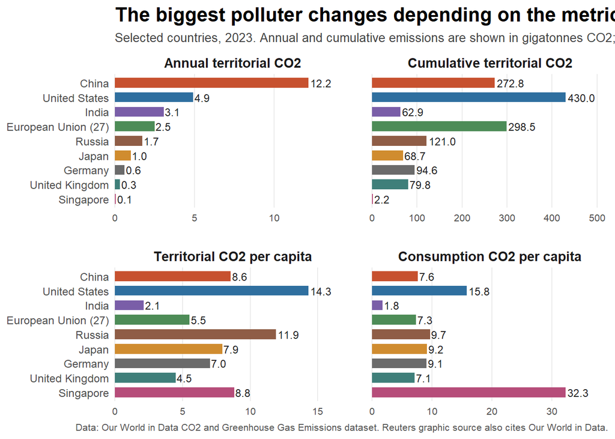

```r
country_palette <- c(
  "China" = "#c7512f",
  "United States" = "#2f6f9f",
  "India" = "#7a5ea8",
  "European Union (27)" = "#4d8c57",
  "EU-27" = "#4d8c57",
  "European Union" = "#4d8c57",
  "Russia" = "#8f5d46",
  "Japan" = "#d08c2f",
  "Germany" = "#6b6b6b",
  "United Kingdom" = "#3f7f7a",
  "Singapore" = "#b64d7a"
)

country_levels <- rev(comparison_countries)

small_multiple_chart <- ggplot(
  plot_data,
  aes(
    x = value,
    y = factor(country, levels = country_levels),
    fill = country
  )
) +
  geom_col(width = 0.68) +
  geom_text(
    aes(label = value_label),
    hjust = -0.08,
    size = 3.1,
    color = "#222222"
  ) +
  facet_wrap(~ metric, scales = "free_x", ncol = 2) +
  scale_fill_manual(values = country_palette, guide = "none") +
  scale_x_continuous(
    labels = label_number(accuracy = 1),
    expand = expansion(mult = c(0, 0.22))
  ) +
  labs(
    title = "The biggest polluter changes depending on the metric",
    subtitle = paste0(
      "Selected countries, ",
      analysis_year,
      ". Annual and cumulative emissions are shown in gigatonnes CO2; per-capita measures are tonnes per person."
    ),
    x = NULL,
    y = NULL,
    caption = "Data: Our World in Data CO2 and Greenhouse Gas Emissions dataset. Reuters graphic source also cites Our World in Data."
  ) +
  theme_minimal(base_size = 11) +
  theme(
    plot.title = element_text(face = "bold", size = 16),
    plot.subtitle = element_text(size = 10, color = "#444444"),
    panel.grid.major.y = element_blank(),
    panel.grid.minor = element_blank(),
    strip.text = element_text(face = "bold", size = 11),
    axis.text.y = element_text(size = 9),
    axis.text.x = element_text(size = 8),
    plot.caption = element_text(size = 8, color = "#555555"),
    panel.spacing = unit(1.2, "lines")
  ) +
  coord_cartesian(clip = "off")

small_multiple_chart
```

```r
ggsave(
  filename = file.path(figures_dir, "co2_metric_small_multiples.png"),
  plot = small_multiple_chart,
  width = 12,
  height = 8,
  dpi = 300
)
```

## Starter interpretation

The first chart draft is meant to support a narrow poster argument:

- Annual territorial emissions emphasize current industrial scale.
- Cumulative territorial emissions emphasize historical responsibility.
- Territorial per-capita emissions emphasize average domestic emissions intensity.
- Consumption-based per-capita emissions shift attention toward demand and trade.

The poster should explain that none of these metrics is a neutral single answer. Each one answers a different policy question.

## Alternative Chart Implementations

This section explores other chart types that could improve upon the original Reuters graphic, focusing on rank shifts across different perspectives.

### Slope Chart (Paired)

The paired slope chart simplifies the comparison by breaking it down into two side-by-side panels. It effectively communicates the change in ranking between two metrics at a time.

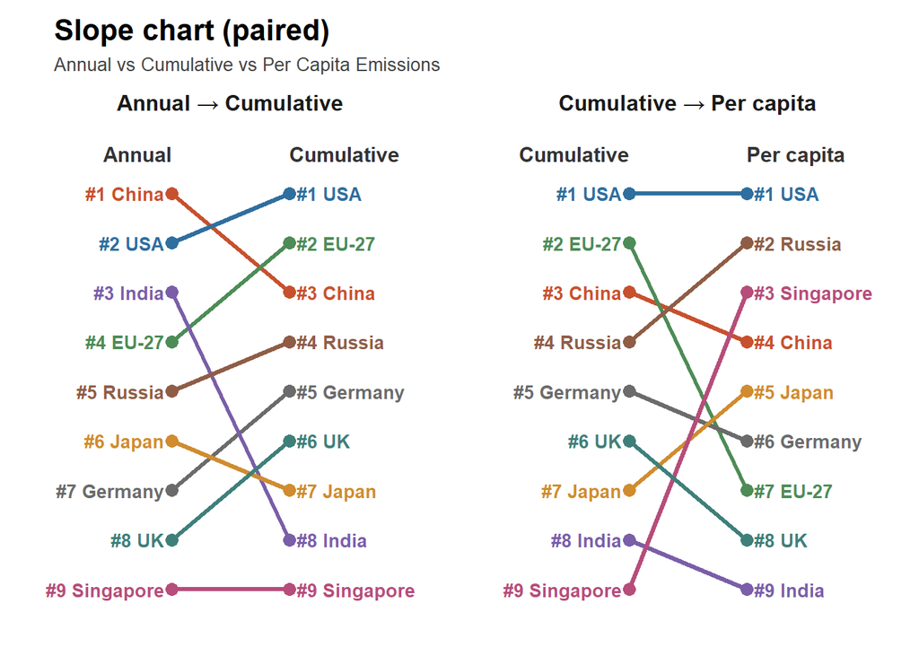

```r
# --- 1. Prepare data for paired slope chart -----------------------------------
slope_rank_data <- plot_data |>
  select(country, metric, rank) |>
  mutate(
    metric_short = case_when(
      metric == "Annual territorial CO2"     ~ "Annual",
      metric == "Cumulative territorial CO2" ~ "Cumulative",
      metric == "Territorial CO2 per capita" ~ "Per capita",
      metric == "Consumption CO2 per capita" ~ "Consumption per cap"
    ),
    country_short = case_when(
      country %in% c("European Union (27)", "EU-27", "European Union") ~ "EU-27",
      country == "United Kingdom" ~ "UK",
      country == "United States"  ~ "USA",
      TRUE                        ~ country
    )
  )

# --- 2. Create two paired comparisons -----------------------------------------
pair1 <- slope_rank_data |>
  filter(metric_short %in% c("Annual", "Cumulative")) |>
  mutate(
    panel = "Annual \u2192 Cumulative",
    x_pos = if_else(metric_short == "Annual", 1, 4)
  )

pair2 <- slope_rank_data |>
  filter(metric_short %in% c("Cumulative", "Per capita")) |>
  mutate(
    panel = "Cumulative \u2192 Per capita",
    x_pos = if_else(metric_short == "Cumulative", 1, 4)
  )

slope_plot_data <- bind_rows(pair1, pair2) |>
  mutate(
    panel      = factor(panel, levels = c("Annual \u2192 Cumulative", "Cumulative \u2192 Per capita")),
    label_text = paste0("#", rank, " ", country_short),
    is_left    = x_pos == 1,
    hjust      = if_else(is_left, 1, 0),
    label_x    = if_else(is_left, x_pos - 0.2, x_pos + 0.2)
  )

# --- 3. Axis column headers ---------------------------------------------------
axis_labels <- data.frame(
  panel = factor(
    c("Annual \u2192 Cumulative", "Annual \u2192 Cumulative",
      "Cumulative \u2192 Per capita", "Cumulative \u2192 Per capita"),
    levels = c("Annual \u2192 Cumulative", "Cumulative \u2192 Per capita")
  ),
  x_pos = c(1, 4, 1, 4),
  y_pos = 0.2,
  label = c("Annual", "Cumulative", "Cumulative", "Per capita"),
  hjust = c(1, 0, 1, 0)
)

# --- 4. Slope chart (paired) --------------------------------------------------
slope_chart <- ggplot(slope_plot_data, aes(y = rank, group = country, colour = country)) +

  geom_line(aes(x = x_pos), linewidth = 1.2) +

  geom_point(aes(x = x_pos), size = 3) +

  geom_text(
    aes(x = label_x, label = label_text, hjust = hjust),
    size     = 3.5,
    fontface = "bold"
  ) +

  geom_text(
    data        = axis_labels,
    aes(x = x_pos, y = y_pos, label = label, hjust = hjust),
    inherit.aes = FALSE,
    fontface    = "bold",
    size        = 4,
    colour      = "#333333"
  ) +

  facet_wrap(~ panel, scales = "free_x") +

  scale_y_reverse(limits = c(max(slope_plot_data$rank) + 0.5, 0)) +

  scale_x_continuous(
    limits = c(-2, 7),
    expand = c(0, 0)
  ) +

  scale_colour_manual(values = country_palette, guide = "none") +

  labs(
    title    = "Slope chart (paired)",
    subtitle = "Annual vs Cumulative vs Per Capita Emissions",
    x        = NULL,
    y        = NULL
  ) +

  theme_minimal(base_size = 11) +
  theme(
    plot.title    = element_text(face = "bold", size = 16),
    plot.subtitle = element_text(size = 10, colour = "#444444"),
    panel.grid    = element_blank(),
    axis.text.y   = element_blank(),
    axis.text.x   = element_blank(),
    strip.text    = element_text(face = "bold", size = 12),
    panel.spacing = unit(4, "lines"),
    plot.margin   = margin(10, 30, 10, 30)
  ) +
  coord_cartesian(clip = "off")

slope_chart
```

```r
ggsave(
  filename = file.path(figures_dir, "co2_slope_chart.png"),
  plot     = slope_chart,
  width    = 14,
  height   = 7,
  dpi      = 300
)
```

### Alluvial Chart

The alluvial chart answers the design question directly: *Who appears most responsible for CO2 emissions under annual, cumulative, per-capita, and consumption-based accounting?*

#### Design Brief Draft

This redesign targets readers of the Reuters Graphics article on CO₂ responsibility. The goal is to reveal how the identity of the “biggest polluter” changes entirely depending on the accounting method used — annual output, historical accumulation, or per-person consumption.

Main revisions:

- Alluvial (flow) chart replacing the original Sankey to show proportional shares and rank shifts simultaneously across four metrics on a common 0-100% scale
- Earthy, desaturated palette drawn from the original’s visual tone, avoiding politically charged colour associations
- Direct bar labels (short country names) to reduce legend switching
- Companion ranking table to make precise rank positions legible at a glance

```r
library(ggalluvial)
```

```r
# --- 1. Shared data setup -----------------------------------------------------

all_metrics <- c(
  "Annual territorial CO2",
  "Cumulative territorial CO2",
  "Territorial CO2 per capita",
  "Consumption CO2 per capita"
)

# Two-line axis labels used on the alluvial y-axis (after coord_flip)
metric_display <- c(
  "Annual territorial CO2"     = "Annual\nterritorial CO2",
  "Cumulative territorial CO2" = "Cumulative\nterritorial CO2",
  "Territorial CO2 per capita" = "Territorial CO2\nper capita",
  "Consumption CO2 per capita" = "Consumption CO2\nper capita"
)

# Design-question text shown to the left of each bar row
metric_questions <- c(
  "Annual territorial CO2"     = "Who is currently emitting the most?",
  "Cumulative territorial CO2" = "Who has polluted most since industrialisation?",
  "Territorial CO2 per capita" = "Where are the largest emissions per person?",
  "Consumption CO2 per capita" = "Who bears most responsibility via consumption?"
)

alluvial_data <- plot_data |>
  filter(as.character(metric) %in% all_metrics) |>
  group_by(metric) |>
  mutate(share = value / sum(value) * 100) |>
  ungroup() |>
  mutate(
    country_short = case_when(
      country %in% c("European Union (27)", "EU-27", "European Union") ~ "EU-27",
      country == "United Kingdom" ~ "UK",
      country == "United States"  ~ "USA",
      TRUE                        ~ country
    ),
    rank_label = paste0("#", rank, " ", country_short),
    # Reverse factor so Annual appears at the TOP after coord_flip()
    metric = factor(metric, levels = rev(all_metrics))
  ) |>
  mutate(country = factor(country, levels = comparison_countries))
```

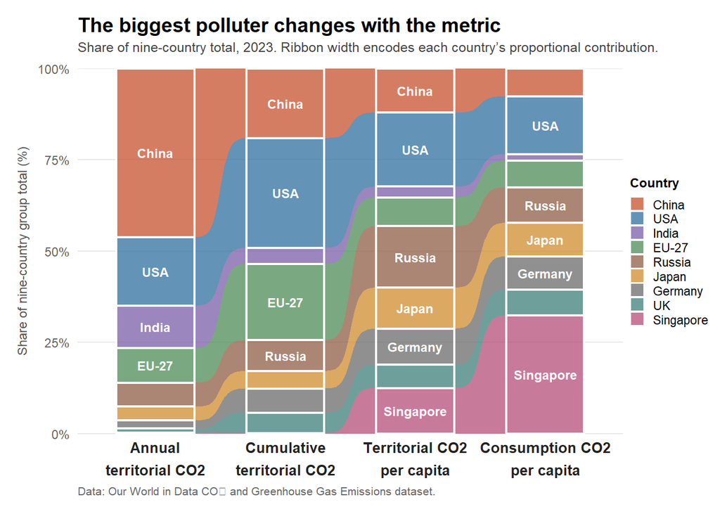

```r
# --- 3. Alluvial chart (vertical, no coord_flip) ------------------------------
# Root fix for long legend labels: map stratum = country_short directly, so
# after_stat(stratum) on bars AND the legend keys both show short names
# ("USA", "EU-27", "UK") with zero extra label-override plumbing.
# A palette keyed on short names (palette_short) replaces country_palette here.

palette_short <- c(
  "China"     = country_palette[["China"]],
  "USA"       = country_palette[["United States"]],
  "India"     = country_palette[["India"]],
  "EU-27"     = country_palette[[
                  intersect(c("European Union (27)", "EU-27", "European Union"),
                            names(country_palette))[1] ]],
  "Russia"    = country_palette[["Russia"]],
  "Japan"     = country_palette[["Japan"]],
  "Germany"   = country_palette[["Germany"]],
  "UK"        = country_palette[["United Kingdom"]],
  "Singapore" = country_palette[["Singapore"]]
)

# Refactor country_short to match palette_short key order
alluvial_plot_data <- alluvial_data |>
  mutate(country_short = factor(country_short, levels = names(palette_short)))

alluvial_chart <- ggplot(
  alluvial_plot_data,
  aes(
    x        = metric,
    y        = share,
    alluvium = country_short,
    stratum  = country_short,
    fill     = country_short
  )
) +

  geom_alluvium(
    alpha      = 0.75,
    curve_type = "sigmoid",
    width      = 0.6
  ) +

  geom_stratum(
    width     = 0.6,
    fill      = NA,
    colour    = "white",
    linewidth = 0.8
  ) +

  # Short names at stratum centroids; suppressed on bands < 8 % share
  geom_text(
    stat     = "stratum",
    aes(label = after_stat(stratum)),
    size     = 3.1,
    colour   = "white",
    fontface = "bold",
    min.y    = 8
  ) +

  scale_fill_manual(
    values = palette_short,
    guide  = guide_legend(
      title          = "Country",
      ncol           = 1,
      keywidth       = unit(0.7, "lines"),
      keyheight      = unit(0.7, "lines"),
      title.position = "top"
    )
  ) +

  scale_x_discrete(
    limits = all_metrics,
    labels = metric_display
  ) +

  scale_y_continuous(
    breaks = seq(0, 100, 25),
    labels = function(y) paste0(y, "%"),
    expand = expansion(mult = c(0, 0)),
    limits = c(0, 100)
  ) +

  labs(
    title    = "The biggest polluter changes with the metric",
    subtitle = paste0(
      "Share of nine-country total, ", analysis_year, ". ",
      "Ribbon width encodes each country’s proportional contribution."
    ),
    x       = NULL,
    y       = "Share of nine-country group total (%)",
    caption = "Data: Our World in Data CO₂ and Greenhouse Gas Emissions dataset."
  ) +

  theme_minimal(base_size = 12) +
  theme(
    plot.title         = element_text(face = "bold", size = 14,
                                      margin = margin(b = 4)),
    plot.subtitle      = element_text(size = 9.5, colour = "#444444",
                                      lineheight = 1.3,
                                      margin = margin(b = 10)),
    plot.caption       = element_text(size = 8, colour = "#666666",
                                      hjust = 0),
    axis.text.x        = element_text(size = 10, colour = "#222222",
                                      face = "bold", lineheight = 1.3,
                                      margin = margin(t = 6)),
    axis.text.y        = element_text(size = 9, colour = "#666666"),
    axis.title.y       = element_text(size = 9, colour = "#555555",
                                      margin = margin(r = 6)),
    panel.grid.major.x = element_blank(),
    panel.grid.minor   = element_blank(),
    panel.grid.major.y = element_line(colour = "#e8e8e8", linewidth = 0.4),
    legend.position    = "right",
    legend.title       = element_text(face = "bold", size = 9),
    legend.text        = element_text(size = 8.5),
    legend.key.size    = unit(0.7, "lines"),
    legend.margin      = margin(l = 2),
    legend.box.spacing = unit(3, "pt"),
    plot.margin        = margin(t = 12, r = 8, b = 12, l = 12),
    plot.background    = element_rect(fill = "white", colour = NA)
  )

alluvial_chart
```

```r
ggsave(
  filename = file.path(figures_dir, "co2_alluvial_chart.png"),
  plot     = alluvial_chart,
  width    = 14,
  height   = 9,
  dpi      = 300
)
```

#### Ranking Table

A separate companion chart lists every country in rank order for each metric, coloured by the same palette as the alluvial ribbons. This lets readers look up precise standings without relying on ribbon width.

```r
# --- 4. Build ranking table data ----------------------------------------------
# Four facets (one per metric) each containing 9 rows (#1 → #9).
# Facet order matches the alluvial chart top-down:
#   Annual → Cumulative → Territorial per capita → Consumption per capita.
# The metric factor must be set to all_metrics (not rev()) so facet_wrap
# displays them left-to-right in the same sequence as the alluvial rows
# read top-to-bottom.

ranking_table <- alluvial_data |>
  select(metric, rank, country, country_short, share) |>
  distinct() |>
  # Re-apply factor in forward all_metrics order for correct facet sequence
  mutate(metric = factor(as.character(metric), levels = all_metrics)) |>
  arrange(metric, rank) |>
  mutate(
    rank_badge  = paste0("#", rank),
    share_label = paste0(round(share, 1), "%"),
    # y position: rank 1 at top (y = -1), rank 9 at bottom (y = -9)
    y_pos       = -rank,
    shade       = (rank %% 2 == 0)
  )
```

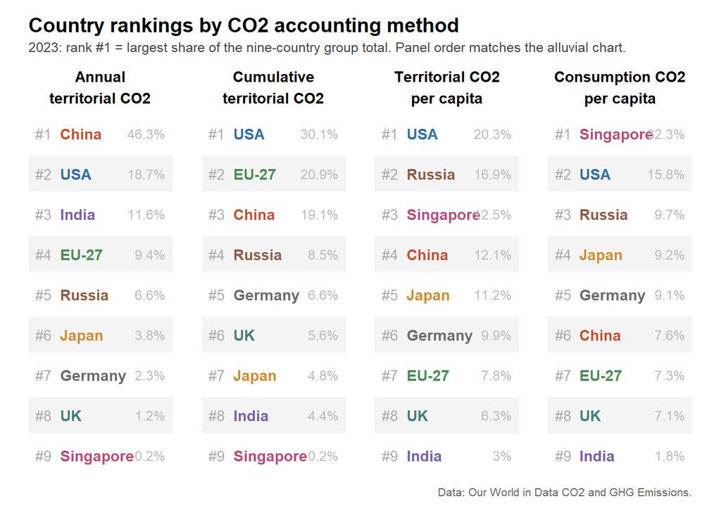

```r
# --- 5. Ranking chart (faceted) -----------------------------------------------
# Four side-by-side panels, one per metric, in the same left-to-right order
# as the alluvial chart reads top-to-bottom (Annual first, Consumption last).
# Three text columns per row: rank badge (grey), country name (colour-coded
# matching the alluvial palette), share % (light grey).
# geom_tile provides alternating row shading within each panel.

ranking_chart <- ggplot(ranking_table, aes(y = y_pos)) +

  # Alternating row shading
  geom_tile(
    data   = ranking_table |> filter(shade),
    aes(x = 0.5, y = y_pos),
    width  = 1,
    height = 0.9,
    fill   = "#f4f4f4",
    colour = NA
  ) +

  # Rank badge — left column
  geom_text(
    aes(x = 0.05, label = rank_badge),
    hjust    = 0,
    size     = 3.5,
    colour   = "#aaaaaa",
    fontface = "plain"
  ) +

  # Country name — middle column, colour-coded with the alluvial palette
  geom_text(
    aes(x = 0.22, label = country_short, colour = country),
    hjust    = 0,
    size     = 3.7,
    fontface = "bold"
  ) +

  # Share % — right column
  geom_text(
    aes(x = 0.95, label = share_label),
    hjust    = 1,
    size     = 3.3,
    colour   = "#bbbbbb"
  ) +

  scale_colour_manual(values = country_palette, guide = "none") +
  scale_x_continuous(limits = c(0, 1), expand = expansion(mult = 0)) +
  scale_y_continuous(expand = expansion(add = c(0.5, 0.5))) +

  # ncol = 4 places all four panels side by side; as_labeller maps factor
  # levels to the two-line short display strings used in the alluvial chart.
  facet_wrap(
    ~ metric,
    ncol     = 4,
    labeller = as_labeller(metric_display)
  ) +

  labs(
    title    = "Country rankings by CO2 accounting method",
    subtitle = paste0(
      analysis_year,
      ": rank #1 = largest share of the nine-country group total.",
      " Panel order matches the alluvial chart."
    ),
    caption = "Data: Our World in Data CO2 and GHG Emissions.",
    x = NULL,
    y = NULL
  ) +

  theme_void(base_size = 12) +
  theme(
    plot.title        = element_text(face = "bold", size = 14,
                                     margin = margin(b = 4)),
    plot.subtitle     = element_text(size = 9.5, colour = "#444444",
                                     margin = margin(b = 10)),
    plot.caption      = element_text(size = 8, colour = "#666666",
                                     margin = margin(t = 8)),
    strip.text        = element_text(face = "bold", size = 10.5,
                                     lineheight = 1.2,
                                     margin = margin(b = 6)),
    panel.spacing.x   = unit(1.4, "lines"),
    plot.margin       = margin(t = 12, r = 20, b = 12, l = 20),
    plot.background   = element_rect(fill = "white", colour = NA)
  )

ranking_chart
```

```r
ggsave(
  filename = file.path(figures_dir, "co2_ranking_chart.png"),
  plot     = ranking_chart,
  width    = 12,
  height   = 6,
  dpi      = 300
)
```

## Next design tasks

- Decide whether to keep the EU aggregate or remove it to avoid mixing countries and regions.
- Add concise annotations beside each panel.
- Add a small supporting rank-change chart only if the poster has enough space.
- Place the original Reuters graphic beside a short critique of the Sankey and rotated-label design.